# Hornbeck 6.14

## 황금분할탐색법

다른 방법들과 달리 원래 함수에 주어진 구간에서 $x$축을 황금비로 나눈 값들을 입력해 보면서 최대값 또는 최소값을 찾아간다. 미분이 전혀 필요하지 않은 것이 장점이지만 그래프를 보고 구간을 정할 필요가 있는 것이 단점이다.

파이썬 함수로 구현:

```python
def GoldenSearch(f, xL, xR, epsilon=1e-10, max_iter=100):
    output = []
    # Corrected golden ratio coefficient
    key_gold = (np.sqrt(5) - 1) / 2

    for i in range(max_iter):
        diff = xR - xL
        x1 = xL + (1 - key_gold) * diff
        x2 = xR - (1 - key_gold) * diff

        fx1 = f(x1)
        fx2 = f(x2)

        output.append(f'#iter {i+1}, res = {abs(xR - xL)}, x1 = {x1}, x2 = {x2}, fx1 = {fx1}, fx2 = {fx2}')

        # Stopping condition
        if abs(xR - xL) < epsilon:
            xm = (xL + xR) / 2
            extreme_value = f(xm)
            output.append('\n\n')
            output.append(f'xm = {xm}, extreme value = {extreme_value}')
            for out in output:
                print(out)
            return xm, extreme_value

        # Update the interval based on function evaluations
        if fx1 < fx2:
            xL = x1
        else:
            xR = x2

    # If max iterations reached without convergence
    xm = (xL + xR) / 2
    extreme_value = f(xm)
    output.append('\n\n')
    output.append(f'Max iterations reached: xm = {xm}, extreme value = {extreme_value}')
    for out in output:
        print(out)
    return xm, extreme_value
```

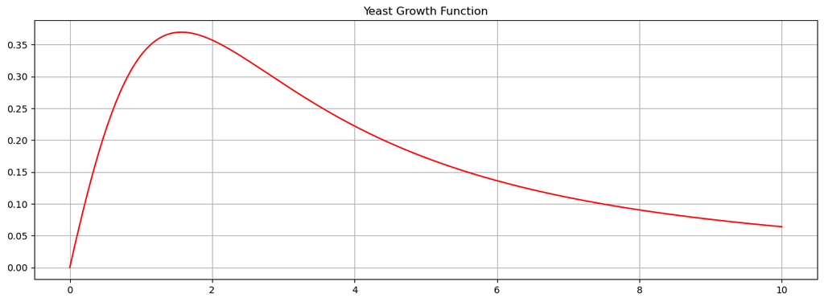

```python
import matplotlib.pyplot as plt

# 효모 성장 함수 g(c)
def g(c):
    return 2 * c / (4 + 0.8 * c + c**2 + 0.2 * c**3)

c = np.linspace(0, 10, 1000)

plt.figure(figsize=(15,5))
plt.plot(c, g(c), c='r')
plt.title('Yeast Growth Function')
plt.grid()
plt.show()
```

```python
xm, extreme_value = GoldenSearch(f=g, xL=0, xR=4)
```

```
#iter 1, res = 4, x1 = 1.5278640450004204, x2 = 2.4721359549995796, fx1 = 0.3694964604867841, fx2 = 0.3272004420454842
#iter 2, res = 2.4721359549995796, x1 = 0.9442719099991588, x2 = 1.5278640450004208, fx1 = 0.3247454520058423, fx2 = 0.36949646048678414
#iter 3, res = 1.5278640450004208, x1 = 1.5278640450004206, x2 = 1.8885438199983178, fx1 = 0.3694964604867841, fx2 = 0.36232557768519846
#iter 4, res = 0.944271909999159, x1 = 1.3049516849970557, x2 = 1.5278640450004208, fx1 = 0.3629250931881388, fx2 = 0.36949646048678414
#iter 5, res = 0.5835921350012621, x1 = 1.5278640450004206, x2 = 1.6656314599949529, fx1 = 0.3694964604867841, fx2 = 0.36886834419772063
#iter 6, res = 0.36067977499789716, x1 = 1.4427190999915878, x2 = 1.5278640450004208, fx1 = 0.36821906641564967, fx2 = 0.36949646048678414
#iter 7, res = 0.22291236000336512, x1 = 1.5278640450004206, x2 = 1.58048651498612, fx1 = 0.3694964604867841, fx2 = 0.3696215238124164
#iter 8, res = 0.13776741499453227, x1 = 1.58048651498612, x2 = 1.6130089900092535, fx1 = 0.3696215238124164, fx2 = 0.3694668202404807
#iter 9, res = 0.08514494500883285, x1 = 1.560386520023554, x2 = 1.58048651498612, fx1 = 0.3696300729253511, fx2 = 0.3696215238124164
#iter 10, res = 0.052622469985699416, x1 = 1.5479640399629866, x2 = 1.560386520023554, fx1 = 0.3696009208573643, fx2 = 0.3696300729253511
#iter 11, res = 0.032522475023133435, x1 = 1.560386520023554, x2 = 1.5680640349255526, fx1 = 0.3696300729253511, fx2 = 0.3696348496743211
#iter 12, res = 0.02009999496256598, x1 = 1.5680640349255526, x2 = 1.5728090000841215, fx1 = 0.3696348496743211, fx2 = 0.3696328110831581
#iter 13, res = 0.012422480060567453, x1 = 1.565131485182123, x2 = 1.5680640349255526, fx1 = 0.3696342081189073, fx2 = 0.3696348496743211
#iter 14, res = 0.007677514901998528, x1 = 1.5680640349255526, x2 = 1.569876450340692, fx1 = 0.3696348496743211, fx2 = 0.3696345187395725
#iter 15, res = 0.004744965158568926, x1 = 1.5669439005972623, x2 = 1.5680640349255526, fx1 = 0.3696347766160237, fx2 = 0.3696348496743211
#iter 16, res = 0.002932549743429602, x1 = 1.5680640349255526, x2 = 1.5687563160124016, fx1 = 0.3696348496743211, fx2 = 0.36963478873442535
#iter 17, res = 0.0018124154151393235, x1 = 1.5676361816841113, x2 = 1.5680640349255526, fx1 = 0.36963484682855746, fx2 = 0.3696348496743211
#iter 18, res = 0.0011201343282902787, x1 = 1.5680640349255528, x2 = 1.5683284627709602, fx1 = 0.36963484967432114, fx2 = 0.3696348359566162
#iter 19, res = 0.0006922810868488227, x1 = 1.567900609529519, x2 = 1.5680640349255526, fx1 = 0.3696348522416743, fx2 = 0.3696348496743211
#iter 20, res = 0.00042785324144123393, x1 = 1.567799607080145, x2 = 1.567900609529519, fx1 = 0.369634851570078, fx2 = 0.3696348522416743
#iter 21, res = 0.0002644278454075888, x1 = 1.5679006095295187, x2 = 1.5679630324761789, fx1 = 0.3696348522416743, fx2 = 0.3696348517941002
#iter 22, res = 0.0001634253960338672, x1 = 1.567862030026805, x2 = 1.567900609529519, fx1 = 0.3696348521888008, fx2 = 0.3696348522416743
#iter 23, res = 0.00010100244937394365, x1 = 1.5679006095295187, x2 = 1.567924452973465, fx1 = 0.3696348522416743, fx2 = 0.3696348521484955
#iter 24, res = 6.242294666014558e-05, x1 = 1.5678858734707513, x2 = 1.5679006095295187, fx1 = 0.3696348522511897, fx2 = 0.3696348522416743
#iter 25, res = 3.8579502713798064e-05, x1 = 1.5678767660855726, x2 = 1.567885873470751, fx1 = 0.3696348522387081, fx2 = 0.36963485225118975
#iter 26, res = 2.3843443946125475e-05, x1 = 1.5678858734707513, x2 = 1.56789150214434, fx1 = 0.3696348522511897, fx2 = 0.36963485225188986
#iter 27, res = 1.4736058767450544e-05, x1 = 1.5678915021443403, x2 = 1.5678949808559297, fx1 = 0.3696348522518899, fx2 = 0.36963485224964365
#iter 28, res = 9.107385178452887e-06, x1 = 1.5678893521823407, x2 = 1.5678915021443403, fx1 = 0.3696348522522549, fx2 = 0.3696348522518899
#iter 29, res = 5.628673588997657e-06, x1 = 1.5678880234327506, x2 = 1.567889352182341, fx1 = 0.3696348522520896, fx2 = 0.36963485225225484
#iter 30, res = 3.4787115896772747e-06, x1 = 1.5678893521823407, x2 = 1.5678901733947501, fx1 = 0.3696348522522549, fx2 = 0.3696348522522077
#iter 31, res = 2.149961999542427e-06, x1 = 1.56788884464516, x2 = 1.5678893521823407, fx1 = 0.36963485225222703, fx2 = 0.3696348522522549
#iter 32, res = 1.3287495901348478e-06, x1 = 1.567889352182341, x2 = 1.5678896658575692, fx1 = 0.36963485225225484, fx2 = 0.36963485225225035
#iter 33, res = 8.212124091855344e-07, x1 = 1.5678891583203882, x2 = 1.567889352182341, fx1 = 0.3696348522522494, fx2 = 0.36963485225225484
#iter 34, res = 5.075371809493134e-07, x1 = 1.5678893521823407, x2 = 1.5678894719956167, fx1 = 0.3696348522522549, fx2 = 0.3696348522522551
#iter 35, res = 3.1367522845826556e-07, x1 = 1.5678894719956165, x2 = 1.5678895460442934, fx1 = 0.3696348522522551, fx2 = 0.36963485225225406
#iter 36, res = 1.9386195271309248e-07, x1 = 1.5678894262310175, x2 = 1.5678894719956167, fx1 = 0.3696348522522553, fx2 = 0.3696348522522551
#iter 37, res = 1.198132759672177e-07, x1 = 1.56788939794694, x2 = 1.5678894262310175, fx1 = 0.3696348522522553, fx2 = 0.3696348522522553
```

[output cut: 19 more lines]

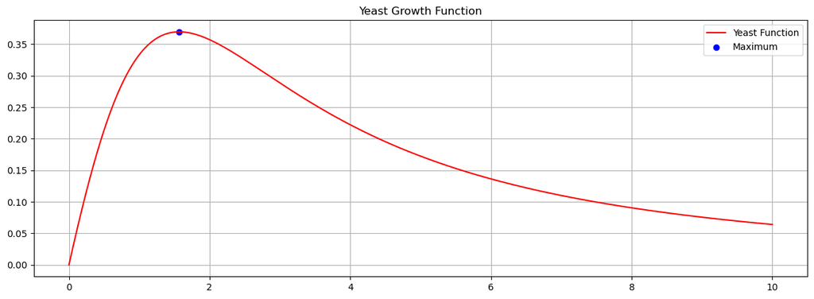

```python
plt.figure(figsize=(15,5))
plt.plot(c, g(c), c='r', label='Yeast Function')
plt.scatter(xm, extreme_value, c='b', label='Maximum')
plt.title('Yeast Growth Function')
plt.legend()
plt.grid()
plt.show()
```

상당히 정확하다.

## 뉴턴-랩슨법

뉴턴-랩슨법을 구현하기 위해선 1계 도함수와 2계 도함수를 알아야 한다.

원래 함수:

$$ g(c) = \frac{2c}{4+0.8c + c^2 + 0.2 c^3} = 2c(4+0.8c + c^2 + 0.2c^3)^{-1} $$

1계 도함수:

$$ f(c) \equiv 2c,\quad g(c) \equiv 4+0.8c + c^2 + 0.2c^3,\quad h(x) \equiv x^{-1} $$

이렇게 치환한 다음 미분의 곱 법칙, 연쇄법칙을 적용하여 풀이한다.

미분의 곱 법칙: $$ (f(c)\cdot h(g(c)))' = f'(c)h(g(c)) + f(c)[h(g(c))]' $$

미분의 연쇄법칙까지 적용: $$ = f'(c)h(g(c)) + f(c)h'(g(c))g'(c) $$

따라서: $$ 2 \cdot (4+0.8c + c^2 + 0.2c^3)^{-1} -2c \cdot (4+0.8c + c^2 + 0.2c^3)^{-2} \cdot (0.8 + 2c + 0.6c^2) $$

다시 분수 표현식으로 바꿔 정리하면:

$$ -\frac{2c(0.8 + 2c + 0.6c^2)}{16(0.05c^3 + c^2/4 + 0.2c + 1)^2} + \frac{2}{4+0.8c + c^2 + 0.2c^3} $$

$$ = \frac{c(-0.8-2c-0.6c^2)}{8(0.05c^2 + c^2/4 + 0.2c + 1)^2} + \frac{2}{4+0.8c + c^2 + 0.2c^3} $$

이것이 1계 도함수이다... 2계 도함수도 어렵게 구해야 할 것이다. 이런 점이 뉴턴-랩슨 방법의 단점이다.

2계 도함수:

첫 번째 항의 도함수: $$ f_1(c) = \frac{c(-0.8 - 2c - 0.6c^2)}{8(0.05c^3 + \frac{c^2}{4} + 0.2c + 1)^2} $$

몫의 법칙 적용: $$ \left( \frac{u}{v} \right)' = \frac{u'v - uv'}{v^2} $$ 여기서:

- $ u = c(-0.8 - 2c - 0.6c^2) $
- $ v = 8(0.05c^3 + \frac{c^2}{4} + 0.2c + 1)^2 $
1. $ u'(c) $ 계산: $$ u = c(-0.8 - 2c - 0.6c^2) $$
   - 곱의 법칙 적용: $$ u' = 1 \cdot (-0.8 - 2c - 0.6c^2) + c \cdot (-2 - 1.2c) $$
     - 결과: $$ u' = -0.8 - 2c - 0.6c^2 - 2c - 1.2c^2 = -0.8 - 4c - 1.8c^2 $$
2. $ v'(c) $ 계산: $$ v = 8(0.05c^3 + \frac{c^2}{4} + 0.2c + 1)^2 $$
   - 연쇄 법칙 및 곱의 법칙 적용: $$ v' = 8 \cdot 2(0.05c^3 + \frac{c^2}{4} + 0.2c + 1) \cdot (0.15c^2 + \frac{c}{2} + 0.2) $$
     - 결과: $$ v' = 16(0.05c^3 + \frac{c^2}{4} + 0.2c + 1)(0.15c^2 + \frac{c}{2} + 0.2) $$
3. $ f_1'(c) $: $$ f_1'(c) = \frac{u'v - uv'}{v^2} $$

두 번째 항의 도함수 $$ f_2(c) = \frac{2}{4 + 0.8c + c^2 + 0.2c^3} $$

몫의 법칙 적용: 여기서:

- $ u = 2 $
- $ v = 4 + 0.8c + c^2 + 0.2c^3 $
1. $ u'(c) = 0 $ (상수항의 도함수)
2. $ v'(c) $: $$ v' = 0.8 + 2c + 0.6c^2 $$
3. $ f_2'(c) $: $$ f_2'(c) = \frac{0 \cdot v - 2 \cdot v'}{v^2} = \frac{-2(0.8 + 2c + 0.6c^2)}{(4 + 0.8c + c^2 + 0.2c^3)^2} $$

전체 도함수 전체 도함수는 두 항의 도함수를 합친 결과: $$ f'(c) = f_1'(c) + f_2'(c) $$

정리:

1. $ f_1'(c) $: $$ f_1'(c) = \frac{(-0.8 - 4c - 1.8c^2)(8(0.05c^3 + \frac{c^2}{4} + 0.2c + 1)^2) - (c(-0.8 - 2c - 0.6c^2))(16(0.05c^3 + \frac{c^2}{4} + 0.2c + 1)(0.15c^2 + \frac{c}{2} + 0.2))}{[8(0.05c^3 + \frac{c^2}{4} + 0.2c + 1)^2]^2} $$
2. $ f_2'(c) $: $$ f_2'(c) = \frac{-2(0.8 + 2c + 0.6c^2)}{(4 + 0.8c + c^2 + 0.2c^3)^2} $$

파이썬의 `sympy`라는 라이브러리는 이런 과정을 그냥 자동으로 해버린다. 그래서 힘들게 코드로 옮겨 적지는 않아도 된다.

```python
import sympy as sp

# 심볼릭 변수 및 효모 성장 심볼릭 함수 정의
c = sp.Symbol('c')
g_expr = 2 * c * (4 + 0.8 * c + c**2 + 0.2 * c**3)**(-1)

# g(c)의 도함수 자동 계산
g_prime = sp.diff(g_expr, c)

g_prime
```

$\displaystyle \frac{c \left(- 0.6 c^{2} - 2 c - 0.8\right)}{8 \left(0.05 c^{3} + \frac{c^{2}}{4} + 0.2 c + 1\right)^{2}} + \frac{2}{0.2 c^{3} + c^{2} + 0.8 c + 4}$

```python
g_2prime = sp.diff(g_prime, c)
g_2prime
```

$\displaystyle \frac{c \left(- 1.2 c - 2\right)}{8 \left(0.05 c^{3} + \frac{c^{2}}{4} + 0.2 c + 1\right)^{2}} + \frac{c \left(- 0.6 c^{2} - 2 c - 0.8\right) \left(- 0.3 c^{2} - c - 0.4\right)}{8 \left(0.05 c^{3} + \frac{c^{2}}{4} + 0.2 c + 1\right)^{3}} + \frac{- 0.6 c^{2} - 2 c - 0.8}{4 \left(0.05 c^{3} + \frac{c^{2}}{4} + 0.2 c + 1\right)^{2}}$

```python
import numpy as np
import sympy as sp

def newton_raphson(func:sp.Expr, var:sp.Symbol, initial_guess:float, tolerance:float = 1e-4, max_iterations:int = 100):
    """
    # Newton-Raphson method to find the maximum of a single-variable function.

    ## Parameters:
        func (sympy expression): The function to maximize.
        var (sympy Symbol): The variable in the function.
        initial_guess (float): The starting point for the iteration.
        tolerance (float): Convergence criterion for the iteration.
        max_iterations (int): Maximum number of iterations.

    Returns:
        output_tuple:
        max_point: The x-coordinate of the maximum point.

        max_value: The maximum value of the function.

        iterations: The number of iterations performed.
    """
    # Compute the first and second derivatives of the function
    first_derivative = sp.diff(func, var)
    second_derivative = sp.diff(first_derivative, var)

    # Initialize variables
    x = initial_guess
    iterations = 0
    xhistory = []
    yhistory = []
    xhistory.append(x)
    yhistory.append(func.subs(var, x))

    for _ in range(max_iterations):
        iterations += 1

        # Evaluate the derivatives at the current point
        f_prime = first_derivative.subs(var, x)
        f_double_prime = second_derivative.subs(var, x)

        # Newton-Raphson update
        if f_double_prime == 0:  # Avoid division by zero
            raise ValueError("Second derivative is zero. Cannot continue.")

        x_new = x - f_prime / f_double_prime

        # Check for convergence
        if abs(x_new - x) < tolerance:
            x = x_new
            break

        x = x_new
        xhistory.append(x)
        yhistory.append(func.subs(var, x))

    max_point = x
    max_value = func.subs(var, max_point)

    return float(max_point), float(max_value), iterations, xhistory, yhistory

x_optimal, y_optimal, num_iter, xhistory, yhistory = newton_raphson(func=g_expr, var=c, initial_guess=2)
print(f'argmax: {x_optimal}, max: {y_optimal}, # of iteration: {num_iter}')
```

```
argmax: 1.5678894233535474, max: 0.36963485225225534, # of iteration: 5
```

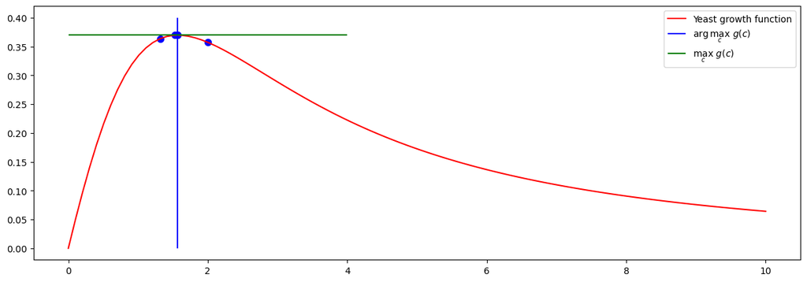

```python
import matplotlib.pyplot as plt # 파이썬 시각화 패키지
import numpy as np # 파이썬 행렬 패키지

plt.rc('text', usetex=False) # 텍스트에 TeX 코드 처리 방법 설정
plt.figure(figsize=(15,5)) # 그래프 사이즈 설정
plt.plot(np.linspace(0, 10, 100), g(np.linspace(0,10,100)), c='r',
         label='Yeast growth function') # 선 그래프 그리기
plt.vlines(x=x_optimal, ymin=0, ymax=0.4, colors=['b'],
           label=r'$\arg \max_{c}\ g(c)$') # 수직선 그리기
plt.hlines(y=g(x_optimal), xmax=4, xmin=0, colors=['g'],
           label=r'$\max_{c}\ g(c)$') # 수평선 그리기
plt.scatter(x=xhistory, y=yhistory, c='b', s=50) # 산점도 그리기
plt.legend() # 범례 표시
plt.show() # 그래프 출력
```

```python
import pandas as pd

pd.DataFrame({'X flow': xhistory, 'g(c) flow': yhistory})
```

|  | X flow | g(c) flow |
| --- | --- | --- |
| 0 | 2 | 0.357142857142857 |
| 1 | 1.31707317073171 | 0.363567183069258 |
| 2 | 1.52872598587180 | 0.369502417560432 |
| 3 | 1.56670810429408 | 0.369634734172597 |
| 4 | 1.56788830536479 | 0.369634852252150 |

뉴턴-랩슨법은 구간을 정해줄 필요가 없는 대신 발산할 위험이 큰데, 이 경우엔 특히 더 그랬다. 초기값을 1 미만 2 초과로 주면 거의 반드시 발산해버리곤 했다.

**발산 예시**

```
argmax: -5756501221704.013, max: 3.0177467971611432e-25, # of iteration: 100
```

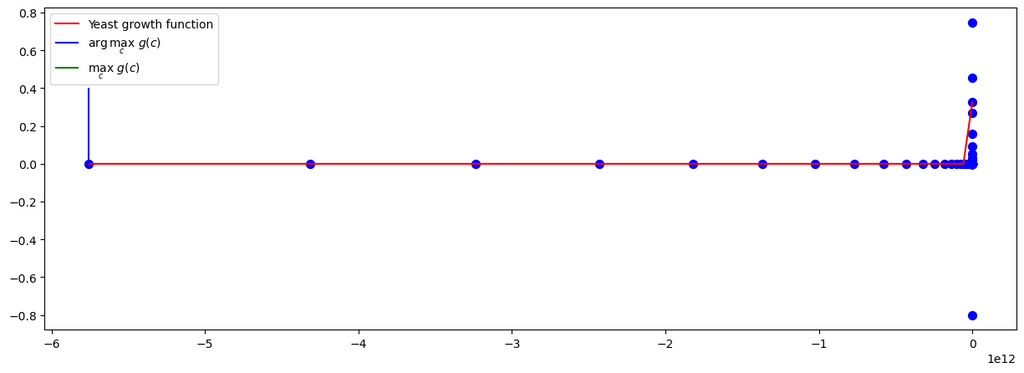

```python
x_optimal, y_optimal, num_iter, xhistory, yhistory = newton_raphson(func=g_expr, var=c, initial_guess=2.5)
print(f'argmax: {x_optimal}, max: {y_optimal}, # of iteration: {num_iter}')

import matplotlib.pyplot as plt # 파이썬 시각화 패키지
import numpy as np # 파이썬 행렬 패키지

plt.rc('text', usetex=False) # 텍스트에 TeX 코드 처리 방법 설정
plt.figure(figsize=(15,5)) # 그래프 사이즈 설정
plt.plot(np.linspace(min(xhistory), max(xhistory), 100), g(np.linspace(min(xhistory),max(xhistory),100)), c='r',
         label='Yeast growth function') # 선 그래프 그리기
plt.vlines(x=x_optimal, ymin=0, ymax=0.4, colors=['b'],
           label=r'$\arg \max_{c}\ g(c)$') # 수직선 그리기
plt.hlines(y=g(x_optimal), xmax=4, xmin=0, colors=['g'],
           label=r'$\max_{c}\ g(c)$') # 수평선 그리기
plt.scatter(x=xhistory, y=yhistory, c='b', s=50) # 산점도 그리기
plt.legend() # 범례 표시
plt.show() # 그래프 출력
```

# Hornbeck 9.18

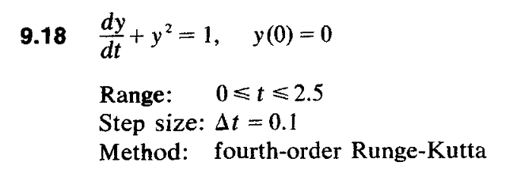

## 해석해 구하기

$ \frac{dy}{dt} + y^2 = 1 $ 분리 변수 형태로 정리:

$$ \frac{dy}{1 - y^2} = dt $$

1단계: 부분 분수 분해

분모 $ 1 - y^2 $을 다음과 같이 분해: $$ 1 - y^2 = (1 - y)(1 + y) $$

따라서: $$ \frac{1}{1 - y^2} = \frac{A}{1 - y} + \frac{B}{1 + y} $$

여기서 $ A $와 $ B $를 구하기 위해 부분 분수 분해를 적용: $$ 1 = A(1 + y) + B(1 - y) $$

$ y = 1 $을 대입하면: $ 1 = 2A \implies A = \frac{1}{2} $  
$ y = -1 $을 대입하면: $ 1 = 2B \implies B = \frac{1}{2} $

따라서: $$ \frac{1}{1 - y^2} = \frac{1/2}{1 - y} + \frac{1/2}{1 + y} $$

2단계: 적분하기

위 식을 적분: $$ \int \frac{1}{1 - y^2} \, dy = \int \left( \frac{1/2}{1 - y} + \frac{1/2}{1 + y} \right) dy $$

각 항을 적분하면: $$ \int \frac{1/2}{1 - y} \, dy = -\frac{1}{2} \ln |1 - y|, \quad \int \frac{1/2}{1 + y} \, dy = \frac{1}{2} \ln |1 + y| $$

따라서: $$ \int \frac{1}{1 - y^2} \, dy = -\frac{1}{2} \ln |1 - y| + \frac{1}{2} \ln |1 + y| = \frac{1}{2} \ln \left| \frac{1 + y}{1 - y} \right| $$

이 식을 미분방정식에 대입: $$ \frac{1}{2} \ln \left| \frac{1 + y}{1 - y} \right| = t + C $$

3단계: $ y $에 대해 풀기

양변에 지수를 취한다: $$ \ln \left| \frac{1 + y}{1 - y} \right| = 2t + 2C $$

$ K = e^{2C} $ (상수)로 두면: $$ \frac{1 + y}{1 - y} = K e^{2t} $$

$ y $를 풀이: $$ 1 + y = (1 - y) K e^{2t} $$

$$ 1 + y = K e^{2t} - K e^{2t} y $$

$$ y (1 + K e^{2t}) = K e^{2t} - 1 $$

$$ y = \frac{K e^{2t} - 1}{1 + K e^{2t}} $$

4단계: 초기 조건으로 $ K $ 구하기

초기 조건 $ t = 0 $에서 $ y(0) = 0 $을 대입: $$ 0 = \frac{K e^{0} - 1}{1 + K e^{0}} $$

$$ 0 = \frac{K - 1}{1 + K} $$

$$ K = 1 $$

따라서: $$ y = \frac{e^{2t} - 1}{e^{2t} + 1} $$

최종 해석해:

$$ \therefore\ y(t) = \frac{e^{2t} - 1}{e^{2t} + 1} $$

## 수치해 구하기

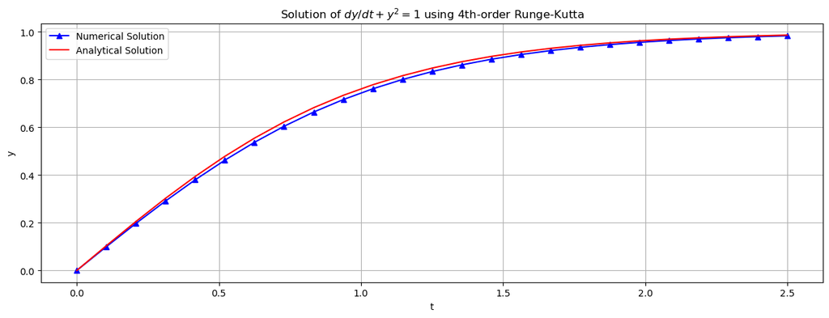

```python
import numpy as np
import matplotlib.pyplot as plt

# 미분 방정식 정의
def f(y, t):
    return 1- y**2

# 해석해 정의
def exact_solution(t):
    return (np.exp(2*t)-1)/(np.exp(2*t)+1)

def RK4(f, y0: float, t0: float, t_end: float, n: int) -> tuple:
    """
    Implements the fourth-order Runge-Kutta (RK4) method to numerically solve
    ordinary differential equations (ODEs) of the form dy/dt = f(y, t).

    Parameters:
        f (callable): The function f(y, t) that defines the ODE.
                      It should take two arguments (y, t) and return the derivative dy/dt.
        y0 (float): Initial value of the dependent variable y at t = t0.
        t0 (float): Initial time value.
        t_end (float): End time value up to which the ODE is solved.
        n (int): Number of time steps (including t0 and t_end).

    Returns:
        tuple: A tuple containing:
            - t_values (numpy.ndarray): Array of time values from t0 to t_end with n points.
            - y_values (numpy.ndarray): Array of y values corresponding to each time value.

    Example:
        >>> import numpy as np
        >>> def f(y, t):
        >>>     return 1 - y**2
        >>> t_values, y_values = RK4(f, y0=0, t0=0, t_end=2.5, n=100)
        >>> print(t_values)
        >>> print(y_values)
    """
    y = np.array(y0, dtype=np.float64)
    t_values = np.linspace(t0, t_end, num=n, endpoint=True, dtype=np.float64)
    delt = (t_end - t0)/n
    y_values = [y0]

    for t in t_values[:-1]:
        y_halfj = y + (delt/2)*f(y, t)
        y_halfj_star = y + (delt/2)*f(y_halfj, t + (delt/2))
        y_next_star = y + delt*f(y_halfj_star, t + (delt/2))
        y = y + delt*((1/6)*f(y, t) + (1/3)*f(y_halfj, t) + (1/3)*f(y_halfj_star, t) + (1/6)*f(y_next_star, t))
        y_values.append(y)

    return t_values, np.array(y_values, dtype=np.float64)


def RK4_2nd(dfz, dfy, y0, z0, t0, t_end, n):
    """
    # Quad-order Runge-Kutta (RK4) method for solving Second-order ODEs.

    ## Parameters:
    - **dfz**: Function dz/dt = f(y, z, t)
    - **dfy**: FUnction dy/dt = z = f(y, z, t)
    - **y0**: Initial value y(t0)
    - **z0**: Initial value z(t0) = dy(t0)/dt
    - **t0**: Initial time
    - **t_end**: End time
    - **n**: Number of points

    Returns:
    - **t_values**: Time points
    - **z_values**: Solution at each time point for z
    - **y_values**: Solution at each time point for y
    """
    t_values = np.linspace(t0, t_end, n, endpoint=True)
    y_values = [y0]
    z_values = [z0]
    delt = (t_end - t0) / (n)  # Step size

    y = y0
    z = z0
    for t in t_values[:-1]:
        z_halfj = z + (delt/2)*dfz(y, z, t)
        y_halfj = y + (delt/2)*dfy(y, z, t)
        z_halfj_star = z + (delt/2)*dfz(y_halfj, z_halfj, t + (delt/2))
        y_halfj_star = y + (delt/2)*dfy(y_halfj, z_halfj, t + (delt/2))
        z_next_star = z + delt*dfz(y_halfj_star, z_halfj_star, t + (delt/2))
        y_next_star = y + delt*dfy(y_halfj_star, z_halfj_star, t + (delt/2))
        z = z + delt*((1/6)*dfz(y, z, t) + (1/3)*dfz(y_halfj, z_halfj, t) + (1/3)*dfz(y_halfj_star, z_halfj_star, t) + (1/6)*dfz(y_next_star, z_next_star, t))
        y = y + delt*((1/6)*dfy(y, z, t) + (1/3)*dfy(y_halfj, z_halfj, t) + (1/3)*dfy(y_halfj_star, z_halfj_star, t) + (1/6)*dfy(y_next_star, z_next_star, t))
        z_values.append(z)
        y_values.append(y)

    return t_values, np.array(z_values), np.array(y_values)

t_values, y_values = RK4(f=f, y0=0, t0=0, t_end=2.5, n=25)

# 결과 시각화
plt.figure(figsize=(15,5))
plt.plot(t_values, y_values, marker='^', c='b', label="Numerical Solution")
plt.plot(t_values, exact_solution(t_values), c='r', label='Analytical Solution')
plt.xlabel("t")
plt.ylabel("y")
plt.title("Solution of $dy/dt + y^2 = 1$ using 4th-order Runge-Kutta")
plt.legend()
plt.grid(True)
plt.show()
```

```python
y_values
```

```
array([0.        , 0.09966791, 0.19737514, 0.29131232, 0.37994854,
       0.46211657, 0.53704879, 0.60436681, 0.66403562, 0.71629656,
       0.76159271, 0.80049748, 0.83365301, 0.86172154, 0.88535005,
       0.9051467 , 0.92166707, 0.93540768, 0.94680472, 0.95623627,
       0.9640265 , 0.97045096, 0.97574226, 0.98009562, 0.98367417])
```

```python
exact_solution(t_values)
```

```
array([0.        , 0.10379153, 0.20537068, 0.30270973, 0.39411857,
       0.47834293, 0.55459972, 0.62255526, 0.68226179, 0.73407152,
       0.77854536, 0.81636904, 0.84828364, 0.87503318, 0.89732841,
       0.91582454, 0.93110961, 0.94370069, 0.95404526, 0.96252574,
       0.96946569, 0.9751367 , 0.97976527, 0.98353937, 0.9866143 ])
```

```python
print('Absolute Percentage Errors:')
(abs(y_values[1:] - exact_solution(t_values[1:]))/abs(y_values[1:])*100).round(4)
```

```
Absolute Percentage Errors:
```

```
array([4.1374, 4.0509, 3.9124, 3.7295, 3.5113, 3.268 , 3.0095, 2.7448,
       2.4815, 2.2259, 1.9827, 1.755 , 1.5448, 1.353 , 1.1797, 1.0245,
       0.8866, 0.7647, 0.6577, 0.5642, 0.4828, 0.4123, 0.3514, 0.2989])
```

$5$% 미만의 오차만 발생하여 매우 우수한 정확도를 보였다.

# Hornbeck 9.27

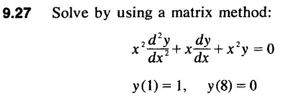

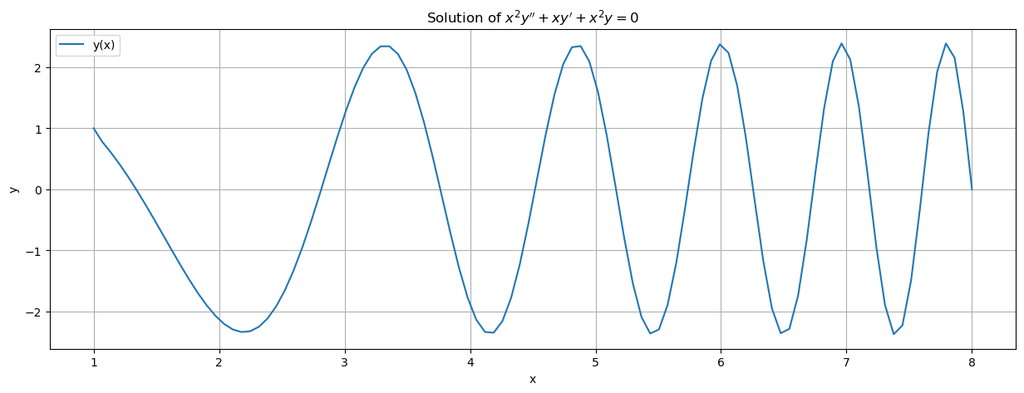

```python
import numpy as np
import matplotlib.pyplot as plt
from scipy.linalg import solve_banded

# 문제 설정
a, b = 1, 8  # x 범위
N = 100  # 구간 수
h = (b - a) / (N + 1)  # 스텝 크기

# x 값 생성
x = np.linspace(a, b, N + 2)

# 행렬 구성 (3-band matrix)
A = np.zeros((3, N))
for i in range(N):
    xi = x[i + 1]
    A[0, i] = 1 / h**2 - 1 / (2 * xi * h)  # 상부 대각선
    A[1, i] = -2 / h**2 + xi**2  # 주 대각선
    A[2, i] = 1 / h**2 + 1 / (2 * xi * h)  # 하부 대각선

# 오른쪽 항 구성 (경계 조건 적용)
B = np.zeros(N)
B[0] = -(1 / h**2 - 1 / (2 * x[1] * h)) * 1  # y(1) = 1
B[-1] = -(1 / h**2 + 1 / (2 * x[-2] * h)) * 0  # y(8) = 0

# 방정식 풀이
y_internal = solve_banded((1, 1), A, B)

# 전체 해 구성 (경계 조건 포함)
y = np.zeros(N + 2)
y[0] = 1  # y(1) = 1
y[1:-1] = y_internal
y[-1] = 0  # y(8) = 0

# 결과 시각화
plt.figure(figsize=(15,5))
plt.plot(x, y, label="y(x)")
plt.xlabel("x")
plt.ylabel("y")
plt.title("Solution of $x^2 y'' + x y' + x^2 y = 0$")
plt.legend()
plt.grid(True)
plt.show()
```

```python
y
```

```
array([ 1.        ,  0.77764236,  0.60173472,  0.40860061,  0.19970754,
       -0.02306618, -0.25735636, -0.50024727, -0.74821927, -0.99711434,
       -1.24212471, -1.47781044, -1.69815175, -1.89664199, -2.06642629,
       -2.20049001, -2.29189906, -2.33409172, -2.32121842, -2.24852153,
       -2.11274312, -1.91254266, -1.648902  , -1.325489  , -0.94894698,
       -0.52907348, -0.07885052,  0.38571047,  0.84594111,  1.28112955,
        1.66938553,  1.98874989,  2.21851979,  2.34073542,  2.34174704,
        2.2137543 ,  1.95618627,  1.57677347,  1.09215638,  0.52788245,
       -0.08233239, -0.69815741, -1.27503272, -1.76732184, -2.13207192,
       -2.33312261, -2.34520993, -2.15763609, -1.7770337 , -1.22875814,
       -0.55650631,  0.18010886,  0.91010302,  1.55760771,  2.04983989,
        2.32580847,  2.34476897,  2.09328101,  1.58969964,  0.88507591,
        0.05977185, -0.78439842, -1.53604809, -2.08896268, -2.3578991 ,
       -2.2931391 , -1.89130134, -1.20011228, -0.31547517,  0.62976226,
        1.48456751,  2.10374521,  2.3736158 ,  2.23485237,  1.69780648,
        0.84638845, -0.17176044, -1.16862528, -1.94969164, -2.35264468,
       -2.283311  , -1.74074464, -0.82460184,  0.27900757,  1.33255422,
        2.09734109,  2.3888444 ,  2.12435702,  1.35030753,  0.24007152,
       -0.94051456, -1.89459403, -2.36941012, -2.22635682, -1.48618049,
       -0.33401924,  0.92145427,  1.92783985,  2.3883805 ,  2.15319391,
        1.27375427,  0.        ])
```